# Tarea 4: Curso herramientas prácticas para investigación reproducible

Maripaz Castro-Murillo, Galit Akerman-Sánchez & Andrea Romero

19/11/2020

### **Corrección trampa 2**

En esta ocasión, se realizan dos modelos diferentes, a partir de la variable de efecto latitudinal (L). Esto se realiza ya que, la especie de estudio tiene un amplio rango de distribución, donde las características de los individuos en zonas templadas y tropicales varía. Viviendo en hábitats tan diferentes como lo son aquellos templados y tropicales, los pájaros pueden presentar variaciones importantes entre ellos por el simple hecho de ser de una zona u otro. Es por esta razón que se realizan dos modelos, evitando así el aumento de la variabilidad entre los individuos muestreados y una desviación estándar alta en los futuros resultados.

Para esto, la variable L, que esta centrada en cero es corregida a su estado normal de la siguiente forma:

```r
Datos_tarea4$L.o <- Datos_tarea4$L*10 + 20 #Para obtener los datos originales en grados
summary(Datos_tarea4$L.o)
```

```
##    Min. 1st Qu.  Median    Mean 3rd Qu.    Max.
##   -0.80   17.20   22.45   22.98   30.02   47.40
```

```r
head(Datos_tarea4) #La base con la variable nueva L.o integrada
```

```
##   A P    L   H1    H2   H3   H4    H5  D  L.o
## 1 1 1 0.03 0.32 -1.01 0.34 2.35 -1.05 22 20.3
## 2 1 1 0.03 0.32 -1.01 0.34 2.35 -1.05 21 20.3
## 3 1 1 0.03 0.32 -1.01 0.34 2.35 -1.05 23 20.3
## 4 1 1 0.03 0.32 -1.01 0.34 2.35 -1.05 21 20.3
## 5 1 1 0.03 0.32 -1.01 0.34 2.35 -1.05 22 20.3
## 6 1 1 0.03 0.32 -1.01 0.34 2.35 -1.05 22 20.3
```

Podemos observar que el punto máximo es de 47.40 y el mínimo de -0.80. Es importante aclarar que revertir esta variable a su forma normal y no centrada en cero, no afecta en nada los resultados del experimento. Este acto fue realizado para poder separar aquellos individuos que se encuentran en zonas templadas y aquellos en zonas tropicales.

Ahora bien, se tomara como referencia el trópico de cáncer que se encuentra a 23.5 grados. Se puede confirmar ingresando al siguiente enlace [Coordenadas Trópico de Cáncer](https://es.wikipedia.org/wiki/Tr%C3%B3pico_de_C%C3%A1ncer). Donde a valores en la variable L.o más altos que 23.5, se tomaran como zona templada, y más bajo que 23.5 como zona tropical.

```r
Zona_templada<- subset(x = Datos_tarea4, subset = L.o > 23.5)
Zona_tropical<- subset(x = Datos_tarea4, subset = L.o < 23.5)
```

A continuación, se realizan gráficos con los grupos de zona templada y zona tropical. Primero se genera la variable categórica de Zona:

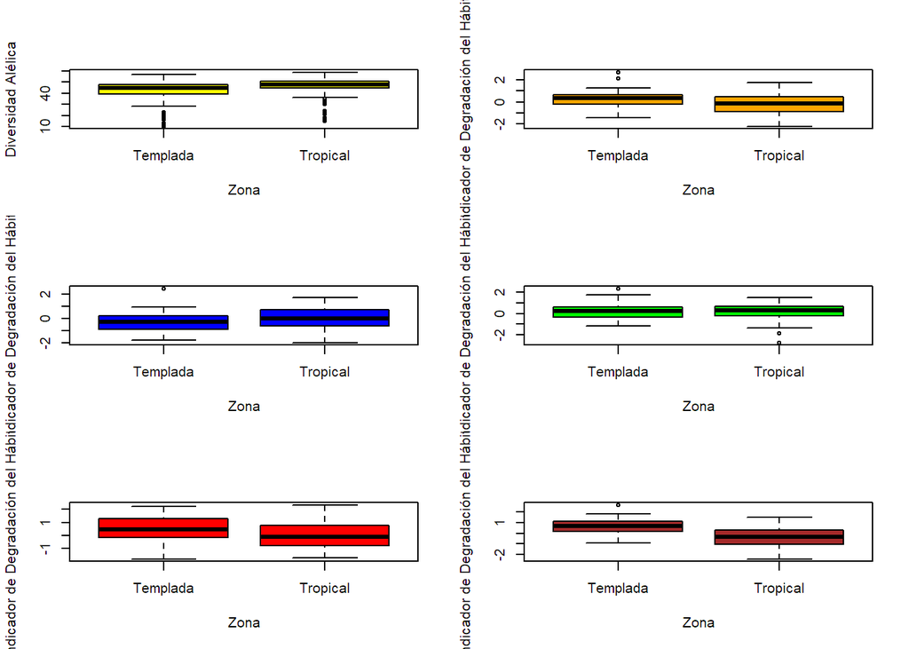

```r
Datos_tarea4$Zona <- ifelse(Datos_tarea4$L.o > 23.5, 1, 0) #Donde 1 son zonas templadas y 0 son zonas tropicales
Datos_tarea4$Zona <- as.character(Datos_tarea4$Zona)
Datos_tarea4$Zona[Datos_tarea4$Zona == '1'] <- 'Templada' #Cambio de nombre: De 1 a Templada
Datos_tarea4$Zona[Datos_tarea4$Zona == '0'] <- 'Tropical' #Cambio de nombre: De 0 a Tropical
par(mfrow=c(3,2))
boxplot(D ~ Datos_tarea4$Zona, ylab = "Diversidad Alélica" , xlab = "Zona", col = "Yellow")
boxplot(H1 ~ Datos_tarea4$Zona, ylab = "Indicador de Degradación del Hábitat 1" , xlab = "Zona", col = "Orange")
boxplot(H2 ~ Datos_tarea4$Zona, ylab = "Indicador de Degradación del Hábitat 2" , xlab = "Zona", col = "Blue")
boxplot(H3 ~ Datos_tarea4$Zona, ylab = "Indicador de Degradación del Hábitat 3" , xlab = "Zona", col = "Green")
boxplot(H4 ~ Datos_tarea4$Zona, ylab = "Indicador de Degradación del Hábitat 4" , xlab = "Zona", col = "Red")
boxplot(H5 ~ Datos_tarea4$Zona, ylab = "Indicador de Degradación del Hábitat 5" , xlab = "Zona", col = "Brown")
```

Se puede evidenciar como algunas variables como la diversidad alélica presentan diferencias en la zonas templadas y en zonas tropicales.

##### **Se realizan los siguientes modelos:**

Los análisis presentados a continuación son independientes entre sí, es decir, se investigó cada zona por aparte el efecto de las variables indicadoras de degradación de hábitat sobre la diversidad alélica del CMH-I de las 60 poblaciones de *P. pajaritus*.

##### -Modelo para ver el efecto de la degradación del hábitat y el efecto latitudinal en la diversidad alélica para poblaciones en zonas templadas:

```r
M.Templado<- lm(D ~ L + H1 + H2 + H3 + H4 + H5 + (1|P), data = Zona_templada)
summary(M.Templado)
```

```
##
## Call:
## lm(formula = D ~ L + H1 + H2 + H3 + H4 + H5 + (1 | P), data = Zona_templada)
##
## Residuals:
##     Min      1Q  Median      3Q     Max
## -13.589  -3.620   1.152   5.094  12.872
##
## Coefficients: (1 not defined because of singularities)
##             Estimate Std. Error t value Pr(>|t|)
## (Intercept) 45.77646    0.98893  46.289  < 2e-16 ***
## L           -0.48464    0.88589  -0.547    0.585
## H1          -3.41070    0.45024  -7.575 6.11e-13 ***
## H2          -3.81761    0.51745  -7.378 2.11e-12 ***
## H3          -2.29830    0.49136  -4.677 4.65e-06 ***
## H4          -6.90892    0.46998 -14.700  < 2e-16 ***
## H5          -0.04243    0.54100  -0.078    0.938
## 1 | PTRUE         NA         NA      NA       NA
## ---
## Signif. codes:  0 '***' 0.001 '**' 0.01 '*' 0.05 '.' 0.1 ' ' 1
##
## Residual standard error: 6.505 on 263 degrees of freedom
## Multiple R-squared:  0.6275, Adjusted R-squared:  0.619
## F-statistic: 73.83 on 6 and 263 DF,  p-value: < 2.2e-16
```

##### -Modelo para ver el efecto de la degradación del hábitat y el efecto latitudinal en la diversidad alélica para poblaciones en zonas tropicales:

```r
M.Tropical <- lm(D ~ L + H1 + H2 + H3 + H4 + H5 + (1|P), data = Zona_tropical)
summary(M.Tropical)
```

```
##
## Call:
## lm(formula = D ~ L + H1 + H2 + H3 + H4 + H5 + (1 | P), data = Zona_tropical)
##
## Residuals:
##     Min      1Q  Median      3Q     Max
## -18.861  -5.121   1.040   4.947  13.458
##
## Coefficients: (1 not defined because of singularities)
##             Estimate Std. Error t value Pr(>|t|)
## (Intercept)  46.3158     0.4892  94.671  < 2e-16 ***
## L             0.5605     0.9140   0.613  0.54016
## H1           -1.2961     0.3969  -3.266  0.00121 **
## H2           -0.2698     0.4215  -0.640  0.52257
## H3            0.8155     0.4327   1.885  0.06035 .
## H4           -5.6896     0.4333 -13.131  < 2e-16 ***
## H5            1.1003     0.4016   2.740  0.00649 **
## 1 | PTRUE         NA         NA      NA       NA
## ---
## Signif. codes:  0 '***' 0.001 '**' 0.01 '*' 0.05 '.' 0.1 ' ' 1
##
## Residual standard error: 6.742 on 323 degrees of freedom
## Multiple R-squared:  0.4458, Adjusted R-squared:  0.4356
## F-statistic: 43.31 on 6 and 323 DF,  p-value: < 2.2e-16
```